# Choloropleth maps in R

CMSC 205, Winter 2017

March 5, 2017

## Toolkit

```r
library(tidyverse) # for out usual plotting and data wrangling tools
library(maps)      # Provides latitude and longitude data for various maps
library(stringr)
library(ggthemes)
```

## Choloropleth maps

A **choropleth map** is a map that shows a geographic landscape with units such as countries, states, or watersheds where each unit is colored according to a particular value.

Today, our goal is to create a chloropleth map of the results of the 2016 presidential election such as the one shown below:

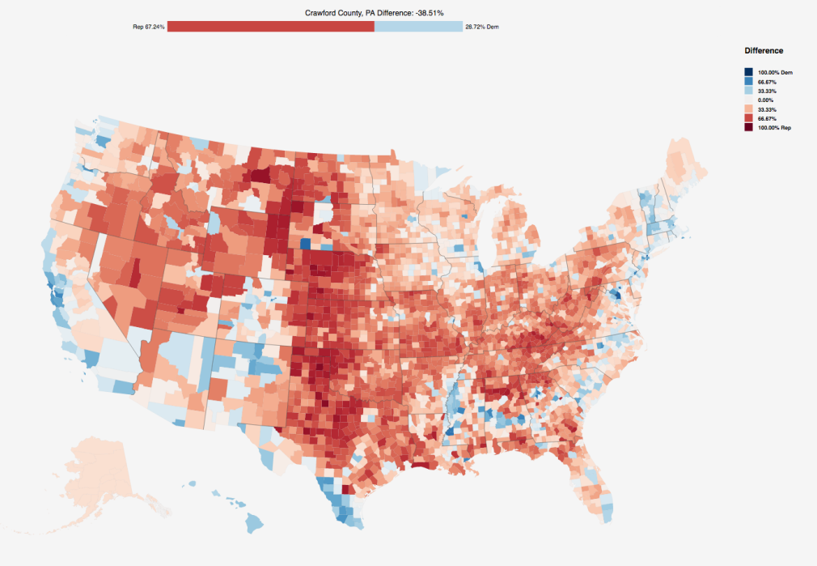

## Polygons

To create such a map, we must plot counties rather than individual coordinates. In this case, we think of our data representing a polygon.

To begin creating such a map, we must load a county-level map data set:

```r
county_map <- map_data("county")
head(county_map)
```

|  | long | lat | group | order | region | subregion |
| --- | --- | --- | --- | --- | --- | --- |
| 1 | -86.50517 | 32.34920 | 1 | 1 | alabama | autauga |
| 2 | -86.53382 | 32.35493 | 1 | 2 | alabama | autauga |
| 3 | -86.54527 | 32.36639 | 1 | 3 | alabama | autauga |
| 4 | -86.55673 | 32.37785 | 1 | 4 | alabama | autauga |
| 5 | -86.57966 | 32.38357 | 1 | 5 | alabama | autauga |
| 6 | -86.59111 | 32.37785 | 1 | 6 | alabama | autauga |

To create a base plot with the outlines of the counties, we can use a `geom_polygon` layer:

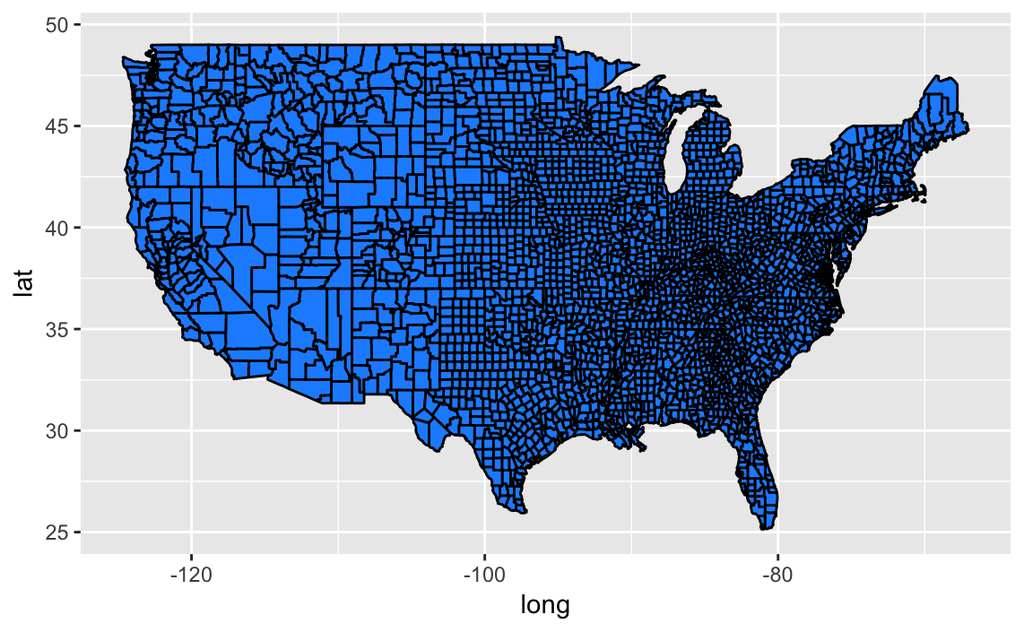

```r
ggplot(county_map, aes(x = long, y = lat, group = group)) +
  geom_polygon(fill="dodgerblue", color = "black")
```

Note: **The order of the rows within each group is extremely important**. For example, is we reshuffle the rows the results are disastrous!

```r
county_map %>%
  sample_frac() %>%
  ggplot(aes(x = long, y = lat, group = group)) +
  geom_polygon(fill="dodgerblue", color = "black")
```

[output not shown]

## Data manipulation

In addition to county-level map data, we also need a data set with the election results:

```r
election <- read_csv("https://github.com/cmsc205/notes/raw/master/day20/2016_US_County_Level_Presidential_Results.csv")
head(election)
```

| None | votes_dem | votes_gop | total_votes | per_dem | per_gop | diff | per_point_diff | state_abbr | county_name | combined_fips |
| --- | --- | --- | --- | --- | --- | --- | --- | --- | --- | --- |
| 0 | 93003 | 130413 | 246588 | 0.3771595 | 0.52887 | 37410 | 15.17 | AK | Alaska | 2013 |
| 1 | 93003 | 130413 | 246588 | 0.3771595 | 0.52887 | 37410 | 15.17 | AK | Alaska | 2016 |
| 2 | 93003 | 130413 | 246588 | 0.3771595 | 0.52887 | 37410 | 15.17 | AK | Alaska | 2020 |
| 3 | 93003 | 130413 | 246588 | 0.3771595 | 0.52887 | 37410 | 15.17 | AK | Alaska | 2050 |
| 4 | 93003 | 130413 | 246588 | 0.3771595 | 0.52887 | 37410 | 15.17 | AK | Alaska | 2060 |
| 5 | 93003 | 130413 | 246588 | 0.3771595 | 0.52887 | 37410 | 15.17 | AK | Alaska | 2068 |

To link the two data sets together, we need to add FIPS codes to the `county_map` data:

```r
# String manipulation to create region and subregion columns
county.fips <- county.fips %>%
  mutate(region = str_extract(polyname, "^[^,]*"),
         subregion = str_extract(county.fips$polyname, "\\,(.*)")) %>%
  mutate(subregion = str_replace(subregion, "\\,", ""))
head(county.fips)
```

|  | fips | polyname | region | subregion |
| --- | --- | --- | --- | --- |
| 1 | 1001 | alabama,autauga | alabama | autauga |
| 2 | 1003 | alabama,baldwin | alabama | baldwin |
| 3 | 1005 | alabama,barbour | alabama | barbour |
| 4 | 1007 | alabama,bibb | alabama | bibb |
| 5 | 1009 | alabama,blount | alabama | blount |
| 6 | 1011 | alabama,bullock | alabama | bullock |

```r
# There are a few counties with NAs, but we can fix that later
county_map <- left_join(x = county_map, y = county.fips)
head(county_map)
```

|  | long | lat | group | order | region | subregion | fips | polyname |
| --- | --- | --- | --- | --- | --- | --- | --- | --- |
| 1 | -86.50517 | 32.34920 | 1 | 1 | alabama | autauga | 1001 | alabama,autauga |
| 2 | -86.53382 | 32.35493 | 1 | 2 | alabama | autauga | 1001 | alabama,autauga |
| 3 | -86.54527 | 32.36639 | 1 | 3 | alabama | autauga | 1001 | alabama,autauga |
| 4 | -86.55673 | 32.37785 | 1 | 4 | alabama | autauga | 1001 | alabama,autauga |
| 5 | -86.57966 | 32.38357 | 1 | 5 | alabama | autauga | 1001 | alabama,autauga |
| 6 | -86.59111 | 32.37785 | 1 | 6 | alabama | autauga | 1001 | alabama,autauga |

Finally, we can merge the two data sets together:

```r
election_map <- left_join(county_map, election, by =  c("fips" = "combined_fips"))
head(election_map)
```

|  | long | lat | group | order | region | subregion | fips | polyname | None | votes_dem | votes_gop | total_votes | per_dem | per_gop | diff | per_point_diff | state_abbr | county_name |
| --- | --- | --- | --- | --- | --- | --- | --- | --- | --- | --- | --- | --- | --- | --- | --- | --- | --- | --- |
| 1 | -86.50517 | 32.34920 | 1 | 1 | alabama | autauga | 1001 | alabama,autauga | 29 | 5908 | 18110 | 24661 | 0.2395685 | 0.7343579 | 12202 | 49.48 | AL | Autauga County |
| 2 | -86.53382 | 32.35493 | 1 | 2 | alabama | autauga | 1001 | alabama,autauga | 29 | 5908 | 18110 | 24661 | 0.2395685 | 0.7343579 | 12202 | 49.48 | AL | Autauga County |
| 3 | -86.54527 | 32.36639 | 1 | 3 | alabama | autauga | 1001 | alabama,autauga | 29 | 5908 | 18110 | 24661 | 0.2395685 | 0.7343579 | 12202 | 49.48 | AL | Autauga County |
| 4 | -86.55673 | 32.37785 | 1 | 4 | alabama | autauga | 1001 | alabama,autauga | 29 | 5908 | 18110 | 24661 | 0.2395685 | 0.7343579 | 12202 | 49.48 | AL | Autauga County |
| 5 | -86.57966 | 32.38357 | 1 | 5 | alabama | autauga | 1001 | alabama,autauga | 29 | 5908 | 18110 | 24661 | 0.2395685 | 0.7343579 | 12202 | 49.48 | AL | Autauga County |
| 6 | -86.59111 | 32.37785 | 1 | 6 | alabama | autauga | 1001 | alabama,autauga | 29 | 5908 | 18110 | 24661 | 0.2395685 | 0.7343579 | 12202 | 49.48 | AL | Autauga County |

## Customizing the map

Now that we have created a base map of the mainland states, we will color each county by the difference between the percentage of voters voting for Trump and Clinton (`per_point_diff`).

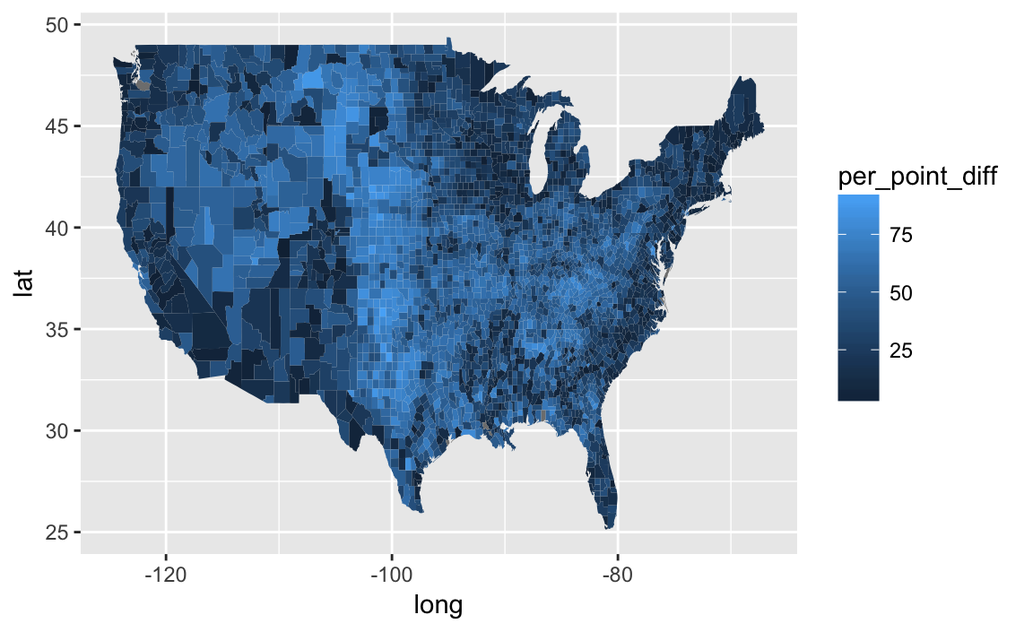

```r
p <- ggplot(election_map, aes(x = long, y = lat, group = group)) +
  geom_polygon(aes(fill = per_point_diff))
p
```

Now that the map is created we can customize it’s appearance.

1. Apply the map theme found in the `ggthemes` package.
2. Adjust the color scheme used on this map to better display the results. Consider using `scale_fill_gradient`, `scale_fill_gradient2`, or `scale_fill_brewer` to help adjust the fill color. Be sure to tweak the legend title.
3. Add an informative title to the map and remove the axis labels
4. Finally, we can change the projection of the map using the `coord_map` layer. There are multiple map projections that could be used, and you can start to read about them in the help file, but for now we will use a polyconic projection. Apply this projection by adding the layer `coord_map(projection = "polyconic")` to your map.